# Association between Income and Depression in NHANES Adults: Draft

## Audience and Questions

This draft is for staff in a municipal public health department who are preparing an internal briefing on health equity. It asks how the family income to poverty ratio is associated with depression symptom scores among adults aged 18 and older in the NHANES 2021–2023 dataset.

## Data and Methods

The file is a combined dataset derived from CDC/NCHS public-use files from NHANES August 2021–August 2023 (Centers for Disease Control and Prevention, National Center for Health Statistics 2026): the depression screener (DPQ_L) and demographics (DEMO_L). Family income was collected in the household interview, and the depression screener was asked at the Mobile Examination Center (MEC). Because the analysis combines both, we use the MEC exam weight `WTMEC2YR` as a participant-level weight for the estimates rather than multiplying it into individual variables. The survey design also accounts for `SDMVSTRA` (masked variance pseudo-stratum) and `SDMVPSU` (masked variance pseudo-PSU). We restricted the file to ages 18 or older, reported missingness, and then used complete records for age, family income to poverty ratio, and depression symptom scores. Of the 6,337 adults in the linked files, 4,831 had both a family income-to-poverty ratio and a usable PHQ-9 total. Following our scoring rule (see `data/README.md`), totals with one or two missing items were prorated, and totals with three or more missing items, or a missing item 9, were left missing.

```r
library(tidyverse)
library(knitr)
library(haven)
library(dplyr)
library(survey)
# AI prompt: Use WTMEC2YR as the participant-level weight for the estimates
#   rather than multiplying it into individual variables.
#   Also account for SDMVSTRA (masked variance pseudo-stratum) and
#   SDMVPSU (masked variance pseudo-PSU).
# Verified: I verified the code Copilot gave me by checking the
#   NHANES documentation and the survey package documentation.
#   The code correctly sets up the survey design using
#   the appropriate weights and stratification variables.

project_root <- normalizePath(
  system2("git", c("rev-parse", "--show-toplevel"), stdout = TRUE),
  mustWork = TRUE
)
nhanes <- read_csv(
  file.path(project_root, "data", "nhanes_merged.csv"),show_col_types = FALSE) |>
  select(SEQN, RIDAGEYR, INDFMPIR, dpq_score, WTMEC2YR, SDMVSTRA, SDMVPSU)

adult_cohort <- nhanes |>
  filter(RIDAGEYR >= 18)

nhanes_design <- svydesign(
  ids = ~SDMVPSU,
  strata = ~SDMVSTRA,
  weights = ~WTMEC2YR,
  nest = TRUE,
  data = nhanes
)
adult_design <- subset(nhanes_design, RIDAGEYR >= 18)

missingness <- tibble(
  variable = c("RIDAGEYR", "INDFMPIR", "dpq_score"),
  missing_n = c(
    sum(is.na(adult_design$variables$RIDAGEYR)),
    sum(is.na(adult_design$variables$INDFMPIR)),
    sum(is.na(adult_design$variables$dpq_score))
  )
)

kable(missingness, caption = "Missingness before complete-case exclusions.")
```

Missingness before complete-case exclusions.

| variable | missing_n |
| --- | --- |
| RIDAGEYR | 0 |
| INDFMPIR | 831 |
| dpq_score | 838 |

```r
analysis_design <- subset(
  adult_design,
  !is.na(INDFMPIR) & !is.na(dpq_score)
)
analysis_df <- analysis_design$variables
```

## Current Results

```r
band_breaks <- c(0, 1, 2, 3, 4, 5, Inf)
band_labels <- c("Under 1", "1 to under 2", "2 to under 3",
                 "3 to under 4", "4 to under 5", "5 or higher")

analysis_df <- analysis_df |>
  mutate(income_band = cut(INDFMPIR, breaks = band_breaks,
                           labels = band_labels, right = FALSE))
analysis_design <- update(
  analysis_design,
  income_band = cut(INDFMPIR, breaks = band_breaks,
                    labels = band_labels, right = FALSE)
)

band_means <- svyby(
  ~dpq_score, ~income_band, analysis_design, svymean, na.rm = TRUE
) |>
  as_tibble() |>
  rename(mean_phq9 = dpq_score)
band_sds <- svyby(
  ~dpq_score, ~income_band, analysis_design, svyvar, na.rm = TRUE
) |>
  as_tibble() |>
  transmute(income_band, sd_phq9 = sqrt(dpq_score))
band_shares <- as.data.frame(prop.table(svytable(~income_band, analysis_design))) |>
  as_tibble() |>
  rename(weighted_share = Freq)
band_counts <- analysis_df |>
  count(income_band, name = "N")

band_summary <- band_means |>
  left_join(band_sds, by = "income_band") |>
  left_join(band_shares, by = "income_band") |>
  left_join(band_counts, by = "income_band")

overall_mean <- as.numeric(coef(svymean(~dpq_score, analysis_design, na.rm = TRUE)))
overall_sd <- sqrt(as.numeric(svyvar(~dpq_score, analysis_design, na.rm = TRUE)))

table1 <- bind_rows(
  tibble(
    income_band = "All adults",
    N = nrow(analysis_df),
    weighted_share = 1,
    mean_phq9 = overall_mean,
    sd_phq9 = overall_sd
  ),
  band_summary
) |>
  mutate(
    income_band = factor(income_band, levels = c("All adults", band_labels)),
    `% of weighted sample` = sprintf("%.1f", 100 * weighted_share),
    `PHQ-9, weighted mean (SD)` = sprintf("%.1f (%.1f)", mean_phq9, sd_phq9)
  ) |>
  select(income_band, N, `% of weighted sample`, `PHQ-9, weighted mean (SD)`) |>
  rename(`Family income-to-poverty ratio` = income_band)

kable(
  table1,
  caption = "Table 1. Unweighted sample counts and survey-weighted estimates for adults overall and by family income-to-poverty ratio. A ratio under 1 means family income below the federal poverty guideline."
)
```

Table 1. Unweighted sample counts and survey-weighted estimates for adults overall and by family income-to-poverty ratio. A ratio under 1 means family income below the federal poverty guideline.

| Family income-to-poverty ratio | N | % of weighted sample | PHQ-9, weighted mean (SD) |
| --- | --- | --- | --- |
| All adults | 4831 | 100.0 | 4.1 (4.7) |
| Under 1 | 731 | 13.4 | 5.6 (5.7) |
| 1 to under 2 | 932 | 18.7 | 5.0 (5.4) |
| 2 to under 3 | 792 | 16.0 | 4.4 (4.8) |
| 3 to under 4 | 618 | 13.8 | 3.8 (4.2) |
| 4 to under 5 | 479 | 10.0 | 3.6 (4.3) |
| 5 or higher | 1279 | 28.1 | 2.9 (3.5) |

Survey-weighted estimates suggest that mean depression symptom scores decrease as family income-to-poverty ratio increases.

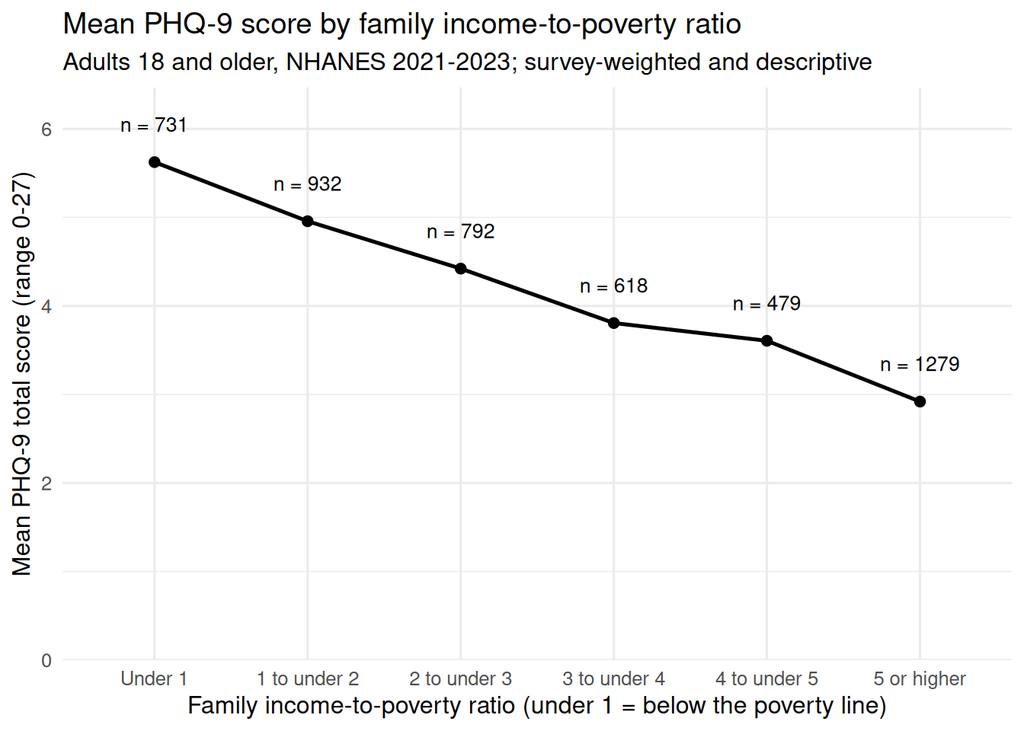

Mean PHQ-9 total score by band of family income-to-poverty ratio among adults aged 18 and older, NHANES 2021-2023. Means are survey-weighted; n labels are unweighted sample counts. Adults missing an income ratio or a PHQ-9 total were excluded. NHANES top-codes the ratio at 5, so the last band includes everyone at 5 or higher. The y-axis starts at 0, the lowest possible score. Values are descriptive, not causal.

```r
income_band_summary <- band_summary |>
  transmute(income_band, n = N, mean_phq9) |>
  filter(n >= 30)
ggplot(income_band_summary, aes(x = income_band, y = mean_phq9, group = 1)) +
  geom_line(linewidth = 0.9) +
  geom_point(size = 2) +
  geom_text(aes(label = paste0("n = ", n)), vjust = -2, size = 3.5) +
  expand_limits(y = 0) +
  scale_y_continuous(expand = expansion(mult = c(0, 0.15))) +
  labs(
    title = "Mean PHQ-9 score by family income-to-poverty ratio",
    subtitle = "Adults 18 and older, NHANES 2021-2023; survey-weighted and descriptive",
    x = "Family income-to-poverty ratio (under 1 = below the poverty line)",
    y = "Mean PHQ-9 total score (range 0-27)"
  ) +
  theme_minimal(base_size = 12)
```

## Draft Interpretation

Survey-weighted mean PHQ-9 scores were lower in each higher income band, from 5.6 among adults below the poverty line to 2.9 among adults at a ratio of 5 or higher (Table 1). The 2.7-point gap is modest next to the spread of scores (weighted SD 4.7), so individual scores overlap a lot between bands. Because the estimates use the NHANES survey weights, they aim to describe U.S. adults rather than only the adults in our sample, but they do not correct for the adults we excluded for missing data. This suggests that lower income is associated with higher depression symptom scores among adults in the NHANES 2021–2023 dataset.

## Limitations

- The analysis is based on cross-sectional data, which limits the ability to infer causality between income and depression.
- Family income and depression assessments are self-reported, which may introduce social desirability and recall biases and potentially lead to misclassification.
- The analysis does not account for potential confounding variables such as employment status, education level, or access to healthcare, which may influence both income and depression.
- The PHQ-9 is a screening tool, not a diagnosis of depression, and may not capture the full spectrum of depressive disorders.
- Adults missing a family income-to-poverty ratio or a PHQ-9 total (see the missingness table) were excluded. The survey weights do not correct for this, so the results could differ if the excluded adults differ from those we kept.

## Draft Next Steps

For the next steps, we suggest examining potential confounders and effect modifiers, such as gender, race/ethnicity, and education level, to better understand the underlying mechanisms of the observed association. Further research could also involve longitudinal studies to assess changes in income and depression over time. That extension is not part of the course project.

### References

Centers for Disease Control and Prevention, National Center for Health Statistics. 2026. “National Health and Nutrition Examination Survey.” https://wwwn.cdc.gov/nchs/nhanes/.